# Part_II_slide_deck_template slides

## Part II - Relationship between Income Range, Prosper Score, Borrower's Rate and Estimated Returns on Prosper Loans

### by Makhura Mandy Rasemphe

## Investigation Overview

- The purpose of the investigation was to look at the relationship of the features that propser loans uses when giving out loans.
- The focus of this investigation will be on the relationship between income range, prosper score, borrower's rate and estimated returns.

## Dataset Overview

The dataset used was from prosper loans and consist of information regarding 113937 loans and 81 features on each loan. No columns or rows were dropped for this investigation.

## Distribution of Income Range

- The distribution of the income range per loan.
- Most loans are distributed amongts the 25, 000 and 49, 999 dollars income range.
- The least loans are distributed amongst the 0 dollars and not employed

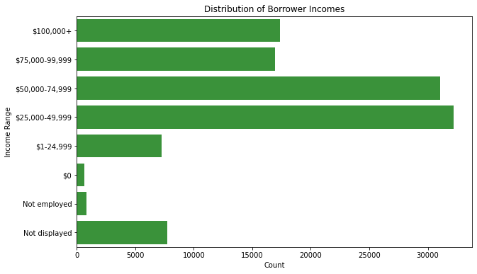

## Distribution of Prosper Score

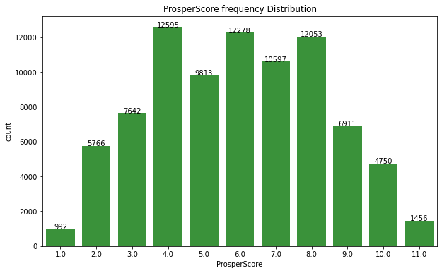

## Distribution of Borrower's Rate

The borrower's rate is slightly skewed to the right with a peak at 0.3

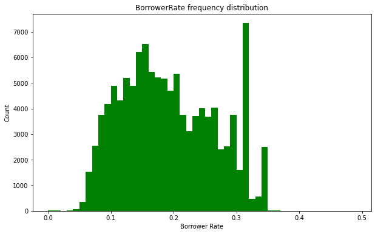

## Distribution of Estimated Return

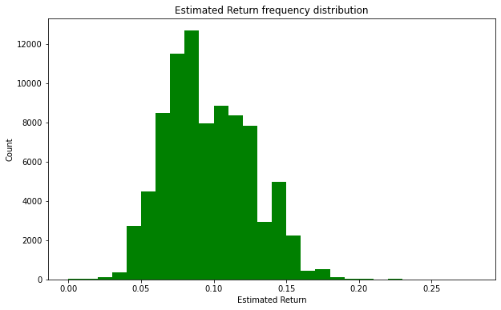

## Relationship between Income Range, Prosper Score and Borrower's Rate

- The plot deicts that mostly The higher the prosper score, the lower the interest range across all income ranges.

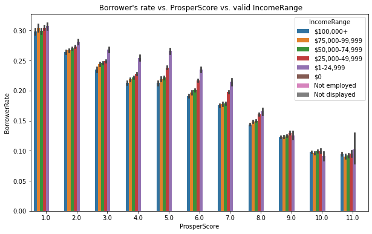

## Relationship Prosper Score, Income Range and Estimated Return

- From plot it can be seen that lower income ranges and lower prosper scores are asscociated with highe estimated returns.

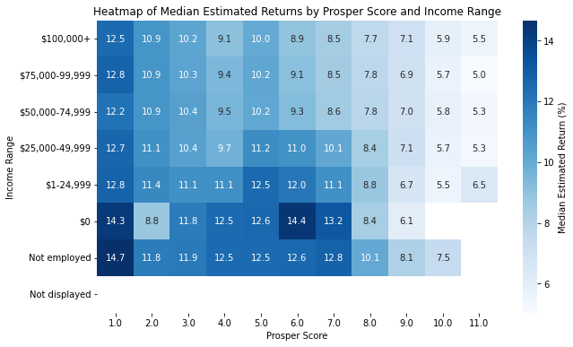